# Homework #2

**See Canvas for this assignment due date**. Complete all of the following problems. Ideally, the theoretical problems should be answered in a Markdown cell directly underneath the question. If you don't know LaTex/Markdown, you may submit separate handwritten solutions to the theoretical problems. Please do not turn in messy work. Computational problems should be completed in this notebook (using the R kernel is preferred). Computational questions may require code, plots, analysis, interpretation, etc. Working in small groups is allowed, but it is important that you make an effort to master the material and hand in your own work.

## A. Theoretical Problems

### Problem A.1

#### Prove that, in the context of simple linear regression, $TSS = RSS + ESS$. Recall that $TSS$ is the total sum of squares, $RSS$ is the residual sum of squares, and $ESS$ is the explained (or model or regression) sum of squares. (HINT: you might start with TSS and add a fancy form of 0 somewhere.)

(Note that this result is true for MLR too, but the proof is a little more involved.)

$$ TSS = \sum^n_{i=1}(y_i - \bar{y})^2 \\ = \sum^n_{i=1}(y_i - \hat{y}_i + \hat{y}_i - \bar{y}) $$

Let $r = y_i - \hat{y}_i$ and $e = \hat{y}_i - \bar{y}$ so, $$ (r + e)^2 = (r+e)(r + e) = r^2 + 2(r)(e) + e^2 $$

Where $r = RSS$ and $e = ESS$. Therefore we want to show that $2(rss)(ess) = 0$, so substituting back in: $$ 2\sum_{i=1}^n (y_i - \hat{y}_i)(\hat{y}_i. - \bar{y}) \\ = 2\sum_{i=1}^n \big[ y_i - \bar{y} + \hat{\beta}_1(\bar{x} - x_i)\big](-\hat{\beta}_1)(\bar{x} - x_i) \hspace{1cm} \text{by} \hspace{0.3cm}\hat{\beta}_0 = \bar{y} - \hat{\beta}_1 \bar{x} \hspace{0.3cm}\text{and}\hspace{0.3cm} \hat{y}_i = \hat{\beta}_0 + \hat{\beta}_1x_i \\ = 2\sum_{i=1}^n -(y_i - \bar{y})\hat{\beta}_1(\bar{x} - x_i) - \hat{\beta}^2_1 (\bar{x} - x_i)^2 \\ = -2\hat{\beta}_1\bigg[\sum_{i=1}^n (y_i - \bar{y})(\bar{x} - x_i) + \hat{\beta}_1\sum_{i=1}^n(\bar{x} - x_i)^2 \bigg]\\ = -2\hat{\beta}_1\bigg[\sum_{i=1}^n (y_i - \bar{y})(\bar{x} - x_i) + \frac{\sum^n_{i=1}\left( x_i - \bar{x}\right)\left(y_i - \bar{y} \right)}{\sum^n_{i=1}\left(x_i - \bar{x}\right)^2}\sum_{i=1}^n(\bar{x} - x_i)^2 \bigg]\hspace{1cm} \text{by} \hspace{0.3cm} \widehat\beta_1 = \frac{\sum^n_{i=1}\left( x_i - \bar{x}\right)\left(y_i - \bar{y} \right)}{\sum^n_{i=1}\left(x_i - \bar{x}\right)^2} \\ = -2\hat{\beta}_1\bigg[\sum_{i=1}^n (y_i - \bar{y})(\bar{x} - x_i) - \sum_{i=1}^n (y_i - \bar{y})(\bar{x} - x_i) \bigg] \\ = -2\hat{\beta}_1\cdot 0 = 0 $$ Hence, $$ TSS = RSS + ESS $$

### Problem A.2: The multivariate normal distribution and its application to regression!

The multivariate normal distribution of an $n$-dimensional vector $\mathbf{Y} = (Y_1,...,Y_n)^T$ can be written in the following notation:

$$\mathbf{Y} \sim N\left(\boldsymbol{\mu}, \Sigma \right),$$

where $\boldsymbol{\mu} = (\underbrace{ \mu_1 }_{E(Y_1)},...,\underbrace{ \mu_n }_{E(Y_n)})^T$ is a vector of means and

$\Sigma = \left(\begin{matrix} \sigma_{Y_1, Y_1} & \sigma_{Y_1, Y_2} & \cdots & \sigma_{Y_1, Y_n} \\ \sigma_{Y_2, Y_1} & \sigma_{Y_2, Y_2} & \cdots & \sigma_{Y_2, Y_n} \\ \vdots & \vdots & \ddots & \vdots \\ \sigma_{Y_n, Y_1} & \sigma_{Y_n, Y_2} & \cdots & \sigma_{Y_n, Y_n} \\ \end{matrix}\right)$

and $\Sigma$ is a *variance-covariance* matrix with entries $\displaystyle \sigma_{Y_i, Y_j} = Cov(Y_i,Y_j)$ for $i,j = 1,...,n$.

What does it mean for a vector to have a *multivariate normal distribution*? It means that, for any constant (i.e., *non-random*) vector $\mathbf{a} = (a_1,a_2,...,a_n)^T$, every linear combination $X = \mathbf{a}^T\mathbf{Y} = a_1Y_1 + a_2Y_2 + ... + a_nY_n$ has a univariate normal distribution with mean $\mu_X = \mathbf{a}^T\boldsymbol{\mu}$ and variance $\sigma_X^2 = \mathbf{a}^T\Sigma\mathbf{a}$.

Further, note that: if $\mathbf{b}$ is an $m\times1$ constant vector, and $B$ is an $m \times n$ constant matrix, then $\mathbf{b} + B\mathbf{Y} \sim N\left(\mathbf{b} + B\boldsymbol\mu, B\Sigma B^T \right)$.

Ok, those were some great properties, and you should make use of them below.

Consider the linear regression model $\mathbf{Y} = X\boldsymbol\beta + \boldsymbol{\varepsilon}$, where $\,\boldsymbol{\varepsilon} {\sim} N(\mathbf{0},\sigma^2I_n)$, $\mathbf{0}$ is an $n\times 1$ vector, and $I_n$ is the $n \times n$ identity matrix.

**A.2 (a) Show that $\varepsilon_i \sim N(0,\sigma^2)$.**

We know that $ \boldsymbol{\varepsilon} = (\epsilon_1,\epsilon_2, ..., \epsilon_n)^T \sim N(\mathbf{0},\sigma^2I_n)$ and $\boldsymbol{a}^T\boldsymbol{\varepsilon} \sim N(\mu_n,\sigma^2_n)$

So we are looking for an $\boldsymbol{a}$ that will result in $\boldsymbol{a}^T\boldsymbol{\varepsilon} = a_1\epsilon_1 + a_2\epsilon_2 + \cdots + a_n\epsilon_n \sim N(0,\sigma^2)$ Therefore $\boldsymbol{a} = (0,0, ..., 1, ..., 0, 0)$ where $1$ is in the $i^{th}$ place so that, $$ \boldsymbol{a}^T\boldsymbol{\varepsilon} = a_1\epsilon_1 + a_2\epsilon_2 + \cdots + a_n\epsilon_n \sim N(0,\sigma^2) = \epsilon_i \sim N(0,\sigma^2) $$

**A.2 (b) Show that $\mathbf{Y} \sim N(X\boldsymbol\beta, \sigma^2I_n)$**

From knowing that $ \boldsymbol{\varepsilon} \sim N(\mathbf{0},\sigma^2I_n)$ and the property given: $$ \mathbf{b} + B\mathbf{Y} \sim N\left(\mathbf{b} + B\boldsymbol\mu, B\Sigma B^T \right) $$ We let $\mathbf{b} = X\boldsymbol\beta$, $\boldsymbol{Y} = \epsilon$, and $B = I_n$ therefore we can describe $\mathbf{Y} = X\boldsymbol\beta + \boldsymbol{\varepsilon}$ as a multivariate normal distribution $\epsilon$. $$ X\boldsymbol\beta + I_n\varepsilon \sim N(X\boldsymbol\beta + I\mu, I_n \Sigma I^T_n) $$

Given from $\varepsilon$ we know that $\mu = 0$ and $\Sigma = \sigma^2I_n$ hence,

$$ X\boldsymbol\beta + I_n\varepsilon \sim N(X\boldsymbol\beta, \sigma^2I_n)\\ \Rightarrow \boldsymbol{Y} \sim N(X\boldsymbol\beta, \sigma^2I_n) $$

**A.2 (c) Let $\boldsymbol{\widehat\beta} $ be the least squares estimator of $\boldsymbol{\beta}$. Prove that $\boldsymbol{\beta}$ has a multivariate normal distribution. What are the mean and variance-covariance matrix?**

We know that $\boldsymbol{Y}$ is a multivariate normal distribution thererfore we can show that $\hat{\beta}$ is a multivariate normal distribution by showing the mean and variance of $\hat\beta$ from $\boldsymbol{Y}$

Mean: $$ E(\hat\beta) = E\bigg((x^TX)^{-1}X^T\boldsymbol{Y}\bigg) = (X^TX)^{-1}X^TE(\boldsymbol{Y}) = (X^TX)^{-1}X^TX\boldsymbol\beta = \boldsymbol\beta $$

Variance: $$ Var(\hat\beta) = Cov(\hat\beta, \hat\beta) = Cov\bigg((X^TX)^{-1}X^T\boldsymbol{Y},(X^TX)^{-1}X^T\boldsymbol{Y} \bigg)\\ = (X^TX)^{-1}X^T Cov(\boldsymbol{Y},\boldsymbol{Y}) [(X^TX)^{-1}X^T]^T \\ = \sigma^2((X^TX)^{-1}X^TX(X^TX)^{-1}) \\ = \sigma^2(X^TX)^{-1} $$

Therefore, $\hat{\boldsymbol\beta} \sim N(\beta,\sigma^2(X^TX)^{-1})$

### Problem A.3

Suppose that, for $i = 1,...,n$, the pairs $(x_i, y_i)$ are generated according to a simple linear regression model

$$Y_i = \beta_0 + \beta_1x_i + \varepsilon_i,$$

where $x_i$ are fixed constants and $\varepsilon_i \overset{iid}{\sim} N(0,\sigma^2)$. Then, imagine reparameterizing the model as

$$Y_i = \beta^*_0 + \beta^*_1\left(x_i- \bar{x}\right) + \varepsilon_i.$$

Let $\widehat\beta_j$ be the least squares estimator of $\beta_j$, and $\widehat\beta^*_j$ be the least squares estimator of $\beta^*_j$ for $j=0,1$.

**A.3 (a) Show that $\widehat\beta^*_1 = \widehat\beta_1$. HINT: For SLR, $\displaystyle \widehat\beta_1 = \frac{\sum^n_{i=1}\left( x_i - \bar{x}\right)\left(y_i - \bar{y} \right)}{\sum^n_{i=1}\left(x_i - \bar{x}\right)^2}$.**

Let $z = (x_i - \bar{x})$, so that: $$ \widehat\beta^*_1 = \frac{\sum^n_{i=1}\left( z_i - \bar{z}\right)\left(y_i - \bar{y} \right)}{\sum^n_{i=1}\left(z_i - \bar{z}\right)^2} $$ And we know that, $$ \bar{z} = \frac{1}{n}\sum^n_{i=1}z_i = \frac{1}{n}\sum^n_{i=1}(x_i - \bar{x}) = \frac{1}{n}\sum^n_{i=1}x_i - \frac{1}{n}\sum^n_{i=1}\bar{x} = \frac{1}{n}n\bar{x} - \frac{1}{n}n\bar{x} = 0 $$ Therefore, $$ \widehat\beta^*_1 = \frac{\sum^n_{i=1}\left( z_i - 0\right)\left(y_i - \bar{y} \right)}{\sum^n_{i=1}\left(z_i - 0\right)^2} \\ \Rightarrow \frac{\sum^n_{i=1}\left(z_i\right)\left(y_i - \bar{y} \right)}{\sum^n_{i=1}\left(z_i\right)^2} \\ \Rightarrow \frac{\sum^n_{i=1}\left( x_i - \bar{x}\right)\left(y_i - \bar{y} \right)}{\sum^n_{i=1}\left(x_i - \bar{x}\right)^2}\\ \Rightarrow \widehat\beta_1 $$

**A.3 (b) Show that, in general, $\widehat\beta^*_0 \ne \widehat\beta_0$, and find $\widehat\beta^*_0$ in terms of $Y_i$. In what particular case is $\widehat\beta^*_0 = \widehat\beta_0$?**

HINT: For SLR, $\widehat\beta_0 = \bar{y} - \widehat\beta_1 \bar{x}$.

Similarly with $A.3a$ we will reparameterize to $z = (x_i-\bar{x})$ and as above we showed that $\bar{z} = 0$ From the hint, $$ \widehat\beta^*_0 = \bar{y} - \widehat\beta^*_1\bar{z} $$

Since we know that $\bar{z} = 0$ we have, $$\widehat\beta^*_0 = \bar{y} \ne \widehat\beta_0$$

The only case where $\widehat\beta^*_0 = \widehat\beta_0$ is when $\bar{x} = 0$.

**A.3 (c) Why might the reparameterized model be beneficial?**

It is often a good idea to reparameterize your model to standardize your predictors so that you can compare the coefficents right and maybe have some standard unit.

### Problem A.4 (STAT 5010 Students Only)

Define the trace of a square matrix

$A = \left(\begin{matrix} a_{1,1} & a_{1,2} & \cdots & a_{1,n} \\ a_{2,1} & a_{2,2} & \cdots & a_{2,n} \\ \vdots & \vdots & \ddots & \vdots \\ a_{n,1} & a_{n,2} & \cdots & a_{n,n} \end{matrix} \right)$

to be $tr(A) = \sum^n_{i=1}a_{i,i}$, i.e., the sum of the diagonal elements of $A$.

**A.4 (a) Let $B$ be a $m \times n$ matrix and $C$ $n\times m$ matrix. Prove that $tr(BC) = tr(CB).$**

We know that $\boldsymbol{B}$ and $\boldsymbol{C}$ is a $m x n$ and $nxm$ matrix, respectively. So, $$ tr(BC) = \sum^m_{k=1} BC_{k,k} \\ \Rightarrow \sum^m_{i=1} \sum^n_{j=1}b_{i,j}c_{j,i} \\ \Rightarrow \sum^n_{j=1} \sum^m_{i=1}c_{j,i}b_{i,j} \hspace{0.25cm} \text{by summation communative property}\\ \Rightarrow \sum^m_{k=1} CB_{k,k} \\ \Rightarrow tr(CB) $$

**A.4 (b) Let $H$ be the hat matrix as defined in class. Prove that $tr(H) = p+1$, where $p$ is the number of parameters in the regression.**

We know the $\boldsymbol{H} = X(X^TX)^{-1}X^T$ so: $$ tr(\boldsymbol{H}) = tr(X(X^TX)^{-1}X^T) \hspace{0.5cm} \text{Let} \hspace{0.1cm} A = X \hspace{0.1cm} \text{and}\hspace{0.1cm} B =(X^TX)^{-1}X^T \\ $$

Then by the above proof, $$ tr(AB) \leftrightharpoons tr(BA) $$

We have, $$ tr((X^TX)^{-1}X^TX) = tr(I_{p + 1}) = p + 1 $$

## B. Computational Problems

```r
library(testthat)
```

### Problem B.1

**B.1 (a) Run a simulation to confirm your result in problem A.3 (a) - (b). Let's do this in parts. In the cell directly below:**

- Set `n = 50`, $\boldsymbol\beta = $ `beta = c(1, 3.5)`.
- Simulate $n$ predictor values ($x$) randomly from $N(3,1)$. Store those values in a variable `x`.
- Simulate $n$ random error terms from $N(0,2)$. Store them in the variable `e`.
- Calculate the response ($y$) according to `y = b0 + b1 x + e`
- Fit a simple linear regression model to the data using the `lm()` function. Store the `lm()` object in a variable `l` and the coefficients of that model in a variable `b1 = coef(l)`.

```r
set.seed(1918)
n = 50; beta = c(1,3.5);
x = rnorm(n, 3, 1)
e = rnorm(n, 0, 2)
y = beta[1] + beta[2]*x + e

Y=data.frame(response = y, predictor = x)
l = lm(response ~ predictor, Y)
summary(l)
b1 = coef(l);
```

```
Call:
lm(formula = response ~ predictor, data = Y)

Residuals:
    Min      1Q  Median      3Q     Max
-4.8629 -1.3586 -0.1809  1.4524  6.6325

Coefficients:
            Estimate Std. Error t value Pr(>|t|)
(Intercept)   0.9936     0.9195   1.081    0.285
predictor     3.5910     0.2985  12.028 4.29e-16 ***
---
Signif. codes:  0 ‘***’ 0.001 ‘**’ 0.01 ‘*’ 0.05 ‘.’ 0.1 ‘ ’ 1

Residual standard error: 2.328 on 48 degrees of freedom
Multiple R-squared:  0.7509,	Adjusted R-squared:  0.7457
F-statistic: 144.7 on 1 and 48 DF,  p-value: 4.288e-16
```

**B.1 (b) Now:**

- **Center the predictor values and store those values in a variable `z`.**
- **Fit a simple linear regression model to the new data, $(z_i, y_i)$, using the `lm()` function. Store the `lm()` object in a variable `l2` and the coefficients of that model in a variable `b2 = coef(l2)` (`b2` shoujld be a vector of length $2$).**
- **In the Markdown cell below the hidden test cell, describe the differences between `b` and `b2`.**

```r
bar_x = mean(x)
z = x - bar_x;

newModel = data.frame(NewPredictor = z, Response = y)
l2=lm(Response ~ NewPredictor, newModel)
b2 = coef(l2);
l
l2
b1; b2
```

```
Call:
lm(formula = response ~ predictor, data = Y)

Coefficients:
(Intercept)    predictor
     0.9936       3.5910
```

```
Call:
lm(formula = Response ~ NewPredictor, data = newModel)

Coefficients:
 (Intercept)  NewPredictor
      11.320         3.591
```

**(Intercept)**

0.993580971529394

**predictor**

3.59099954430304

**(Intercept)**

11.3199210779158

**NewPredictor**

3.59099954430304

The main difference from `b1` and `b2` is the intercepts. The centered predictor values (`NewPredictor`) are larger than `b1`'s. The predictor values themselves are the same however.

**B.1 (c) Now confirm A.4 (b) using the model from B.1 (b) (STAT 4010 students, you will do this too, even though you don't have to do A.4 (b) above). That is, compute the hat matrix, and then compute its trace (sum of the diagonals). Store your answer in `pp1`. (To do this quickly, you can use the `tr()` function in the `psych` package. You'll probably need to install the package in Anaconda.)**

```r
library(psych)
X = cbind(1, z)
h = X%*%solve(t(X)%*%X)%*%t(X)
pp1 = tr(h)
pp1
```

2

### Problem B.2

This [link](https://www.colorado.edu/amath/sites/default/files/attached-files/advertising.txt) contains advertising data. This dataset contains, in thousands of dollars, TV, Radio, and Newspaper budgets for 200 different markets along with the Sales, in thousands of units, for each market.

In the cell directly below, I load the dataset using the link above. Explore it graphically and numerically and note whether there relationships between variables.

In any tests below, let $\alpha = 0.05$.

```r
library(tidyverse)  # data manipulation and visualization
library(modelr)     # provides easy pipeline modeling functions
library(broom)      # helps to tidy up model outputs
library(ggplot2)
# Load data (remove row numbers included as X1 variable)
adv = read.csv("https://www.colorado.edu/amath/sites/default/files/attached-files/advertising.txt", sep = "\t")
adv = adv[,-1]
head(adv)
```

| TV | radio | newspaper | sales |
| --- | --- | --- | --- |
| 230.1 | 37.8 | 69.2 | 22.1 |
| 44.5 | 39.3 | 45.1 | 10.4 |
| 17.2 | 45.9 | 69.3 | 9.3 |
| 151.5 | 41.3 | 58.5 | 18.5 |
| 180.8 | 10.8 | 58.4 | 12.9 |
| 8.7 | 48.9 | 75.0 | 7.2 |

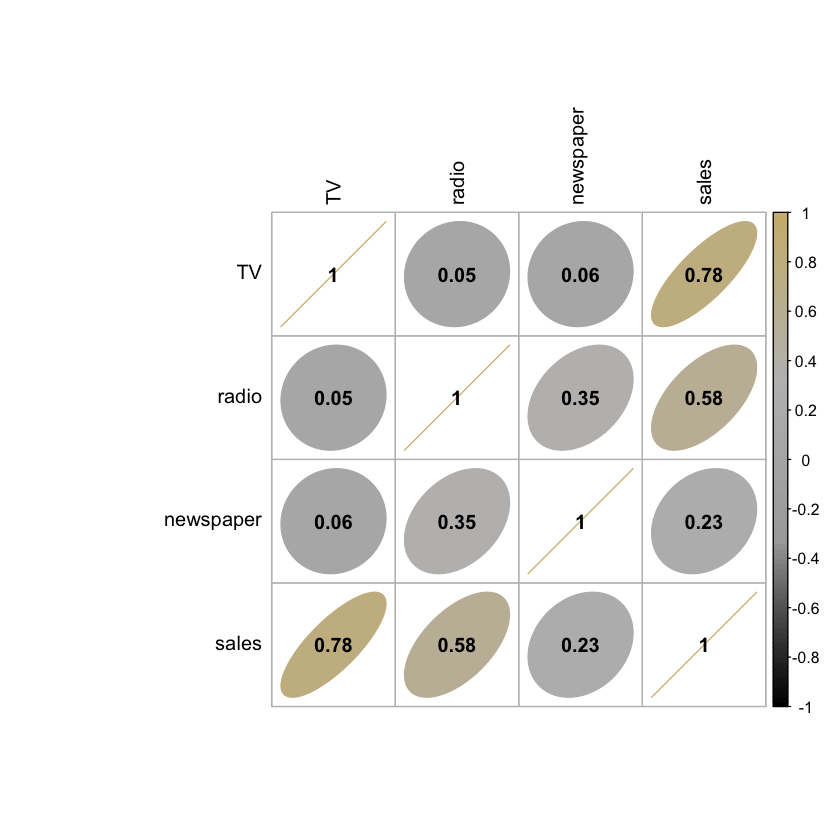

```
       TV             radio          newspaper          sales
 Min.   :  0.70   Min.   : 0.000   Min.   :  0.30   Min.   : 1.60
 1st Qu.: 74.38   1st Qu.: 9.975   1st Qu.: 12.75   1st Qu.:10.38
 Median :149.75   Median :22.900   Median : 25.75   Median :12.90
 Mean   :147.04   Mean   :23.264   Mean   : 30.55   Mean   :14.02
 3rd Qu.:218.82   3rd Qu.:36.525   3rd Qu.: 45.10   3rd Qu.:17.40
 Max.   :296.40   Max.   :49.600   Max.   :114.00   Max.   :27.00
```

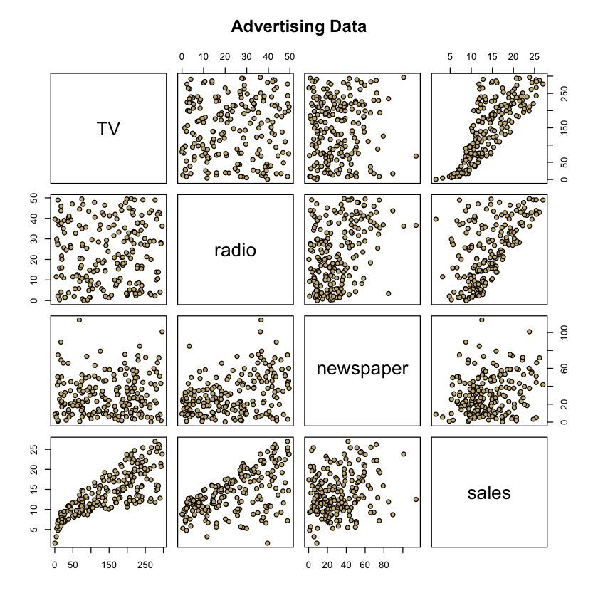

```r
library(corrplot)
col4 = colorRampPalette(c("black", "darkgrey", "grey", "#CFB87C"))
corrplot(cor(adv), method = "ellipse", col = col4(100), addCoef.col = "black", tl.col = "black")
plot(adv,main = "Advertising Data",pch = 21, bg = c("#CFB87C"))
summary(adv)
```

Explore it graphically and numerically and note whether there relationships between variables

Looks at the plots and ellipses we can see that TV and Sales seem to have a non-linear trend, sales vs radio appear to have a linear trend, and sales to newspaper have a random look. TV and radio have no correlation while radio to newspaper has low trend.

Numerically, TV has a large attribute to sales, then radio, and lastly newspaper. All other relationships don't have much affect on each other.

**B.2 (a) Perform MLR, using sales as the response and all other variables as predictors. Store the resulting `lm()` object in `mlr_sales`.**

```r
mlr_sales = lm(sales ~ TV + radio + newspaper, data = adv)
summary(mlr_sales)
```

```
Call:
lm(formula = sales ~ TV + radio + newspaper, data = adv)

Residuals:
    Min      1Q  Median      3Q     Max
-8.8277 -0.8908  0.2418  1.1893  2.8292

Coefficients:
             Estimate Std. Error t value Pr(>|t|)
(Intercept)  2.938889   0.311908   9.422   <2e-16 ***
TV           0.045765   0.001395  32.809   <2e-16 ***
radio        0.188530   0.008611  21.893   <2e-16 ***
newspaper   -0.001037   0.005871  -0.177     0.86
---
Signif. codes:  0 ‘***’ 0.001 ‘**’ 0.01 ‘*’ 0.05 ‘.’ 0.1 ‘ ’ 1

Residual standard error: 1.686 on 196 degrees of freedom
Multiple R-squared:  0.8972,	Adjusted R-squared:  0.8956
F-statistic: 570.3 on 3 and 196 DF,  p-value: < 2.2e-16
```

**B.2 (b) Describe the full F-test for this model. Be sure to clearly state the null and alternative hypotheses, the test statistic, p-value, and decision.**

In our case the null hypothesis is the null model. Therefore $H_0: \omega$ and the alternative hypothesis is the full model, $H_1: \Omega$, meaning the reduced model is not sufficient enough to provide evidence. The test statistic we are applying is the F-statistics.

The F-statistic will note if the null model has sufficent evidence. We notice that the p-value is significantly smaller than $0.05$ therefore the we have evidence to reject the null model.

**B.2 (c) Is there good evidence to suggest that newspaper advertising has a *negative* association with sales? Use a statistical test as justification.**

This also depends on what it means to the data scientist who is analyzing these numbers.

**B.2 (d) Assume that the model is correct. How much variability in `sales` is being explained by the model `mlr_sales`? Store your answer, rounded to four digits, in `v` below.**

```r
anovaSales = anova(mlr_sales)
tss = sum(anovaSales$`Sum Sq`)
rss = anovaSales[4,2]
v = round(1 - rss/tss, 4)
v
```

0.8972